# Time Series Analysis and Model Diagnostics

### Autocorrelation Analysis of the Color Property Time Series

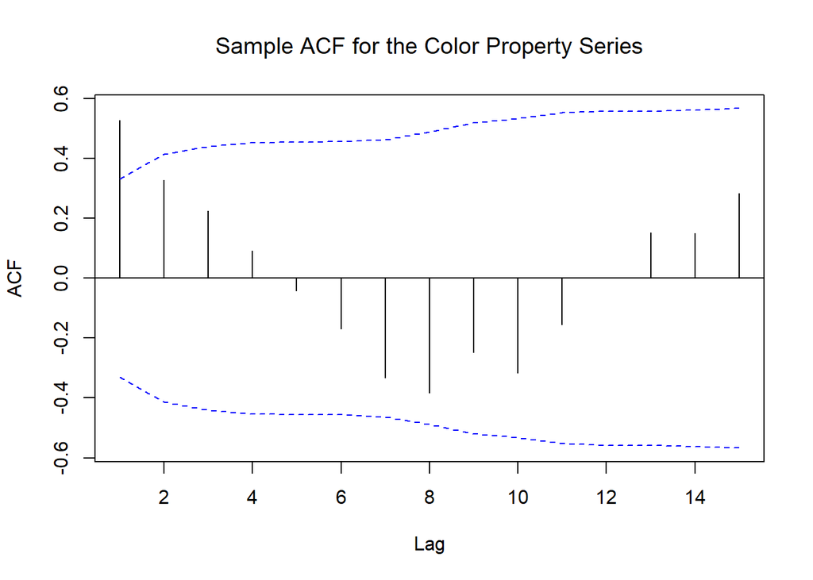

```r
data(color)
acf(color,ci.type='ma', xaxp=c(0,20,10),
main = expression("Sample ACF for the Color Property Series"))
```

The autocorrelation function (ACF) plot depicts the serial correlation structure of the “color” property time series, using moving average (MA) confidence bounds. The data exhibits strong positive autocorrelation at lag 1, with the correlation gradually declining and crossing into negative territory around lag 6–10. This behavior suggests the presence of short-term memory and possible oscillatory tendencies in the series.

Notably, the spike at lag 1 exceeds the 95% MA-based confidence bounds, indicating statistically significant autocorrelation. Several smaller spikes appear near lags 13–15, suggesting subtle longer-term structure or noise artifacts. The overall decay and alternating signs reflect the series’ moderate persistence and complexity, warranting potential modeling via ARMA processes for improved forecasting or interpretation.

### Partial Autocorrelation Analysis of the Color Property Time Series

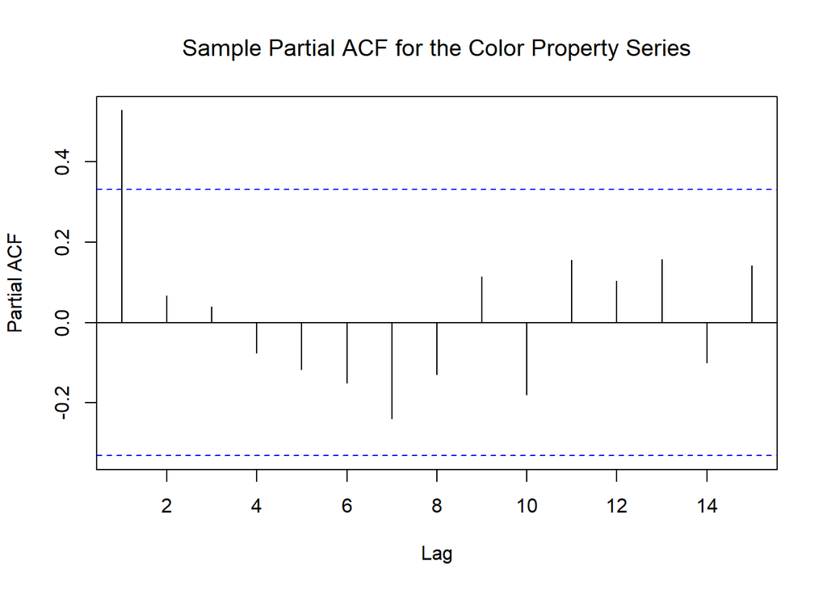

```r
data(color)
pacf(color, xaxp=c(0,20,10),
main = expression("Sample Partial ACF for the Color Property Series"))
```

The partial autocorrelation function (PACF) plot provides insights into the direct dependencies within the “color” property time series, independent of intermediate lags. A prominent spike at lag 1 indicates strong direct correlation with the immediately preceding observation, suggesting potential suitability for AR(1)-type modeling. All subsequent lags fall within the 95% confidence bounds, implying the absence of significant higher-order direct relationships.

This pattern is characteristic of an autoregressive process of order 1, where only the first lag contributes substantial predictive value. The flatness of the PACF beyond lag 1 further confirms a lack of deeper lag structure. A minor upward bump near lag 13 may reflect noise or a weak seasonal effect, but it does not exceed the significance threshold.

### Box-Cox Power Transformation Analysis for Hare Abundance

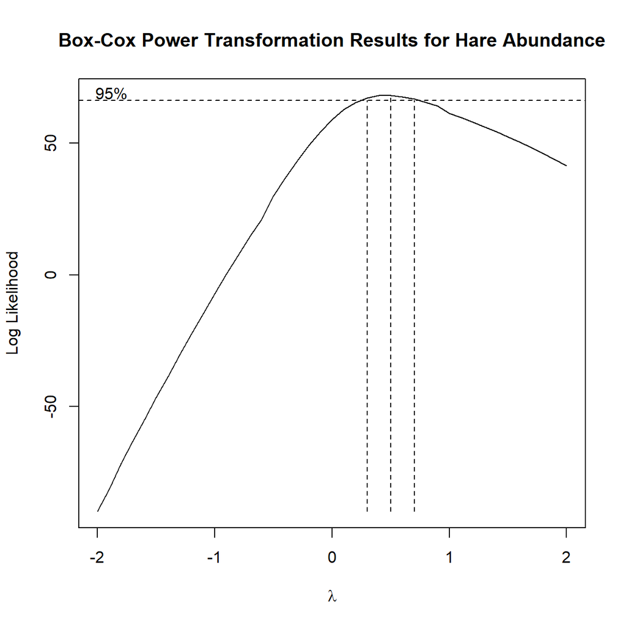

```r
data(hare)
BoxCox.ar(hare, plotit = TRUE)
title(main = "Box-Cox Power Transformation Results for Hare Abundance")
```

The plot displays the log-likelihood profile for the Box-Cox power transformation applied to the hare abundance time series. The horizontal axis represents the transformation parameter $\lambda$, while the vertical axis shows the corresponding log-likelihood values. The peak of the curve indicates the value of $\lambda$ that maximizes the log-likelihood, which is the optimal transformation for achieving normality and stabilizing variance.

The dashed vertical lines denote the bounds of the 95% confidence interval for $\lambda$, suggesting that a range of values within this interval would be statistically acceptable for transformation. In this case, the optimal $\lambda$ lies close to 0.5, indicating that a square root or similar transformation may be appropriate. This diagnostic is crucial in time series preprocessing, particularly when preparing data for ARIMA modeling where homoscedasticity and normality of residuals are often assumed.

### ACF for Square Root of Hare Abundance

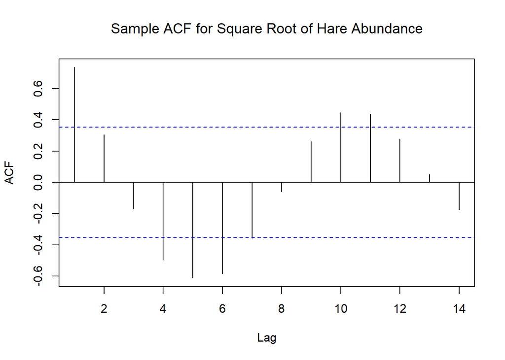

```r
data(hare)
acf(hare^.5, xaxp=c(0,20,10),
main = expression("Sample ACF for Square Root of Hare Abundance"))
```

The autocorrelation function (ACF) plot displays the sample autocorrelations of the square-root-transformed hare abundance time series. This transformation was motivated by the Box-Cox analysis, which suggested a $\lambda$ value close to 0.5 as optimal for variance stabilization.

Overall, the transformation appears effective in stabilizing variance while preserving essential temporal structure, making the series more suitable for further modeling with ARIMA-type methods.

### PACF for Square Root of Hare Abundance

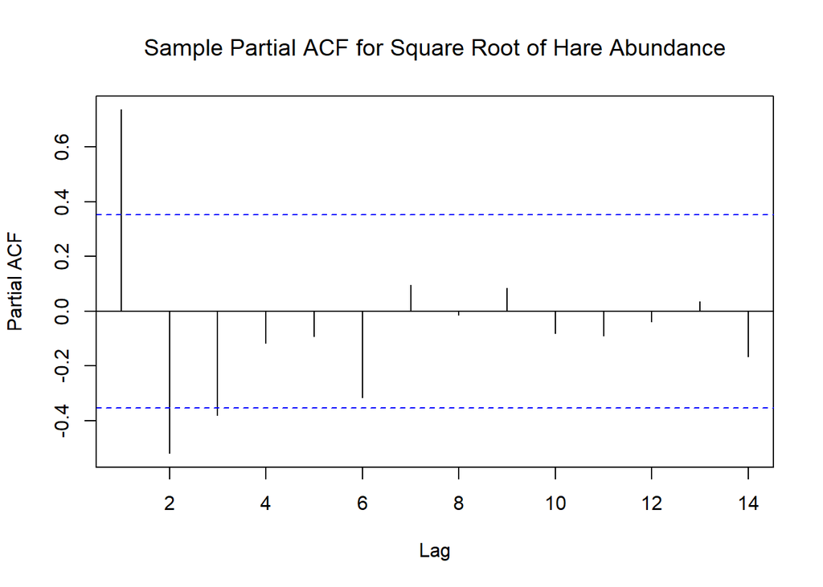

```r
data(hare)
pacf(hare^.5, xaxp=c(0,20,10),
main = expression("Sample Partial ACF for Square Root of Hare Abundance"))
```

The partial autocorrelation function (PACF) plot for the square-root-transformed hare abundance series reveals the direct dependencies between observations after removing the effect of intermediate lags.

```r
data(oil.price)
eacf(diff(log(oil.price)))
```

```
## AR/MA
##   0 1 2 3 4 5 6 7 8 9 10 11 12 13
## 0 x o o o o o o o o o o  o  o  o
## 1 x x o o o o o o o o x  o  o  o
## 2 o x o o o o o o o o o  o  o  o
## 3 o x o o o o o o o o o  o  o  o
## 4 o x x o o o o o o o o  o  o  o
## 5 o x o x o o o o o o o  o  o  o
## 6 o x o x o o o o o o o  o  o  o
## 7 x x o x o o o o o o o  o  o  o
```

### BIC-Based ARMA Subset Selection for Differenced Log Oil Price Series

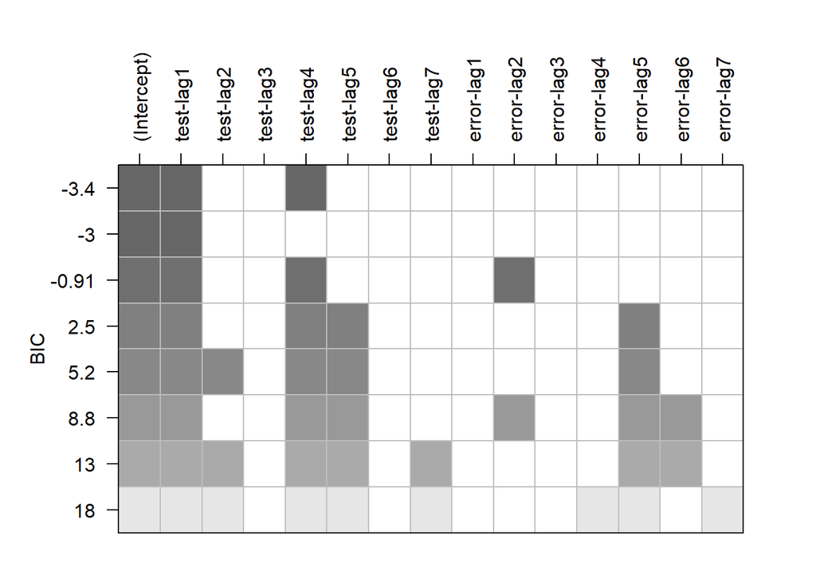

```r
res=armasubsets(y=diff(log(oil.price)),nar=7,nma=7,y.name='test', ar.method='ols')
plot(res)
```

This heatmap visualizes the results of subset selection using the Bayesian Information Criterion (BIC) for ARMA models fitted to the differenced logarithmic oil price series. The rows represent BIC values for various model configurations, while the columns indicate the inclusion of autoregressive (`test-lag`) and moving average (`error-lag`) terms up to lag 7.

This plot aids in pinpointing the best ARMA(p,q) structure by balancing model complexity with goodness-of-fit, serving as a diagnostic guide before final model estimation.

### Sample ACF of Differenced Logged Oil Prices

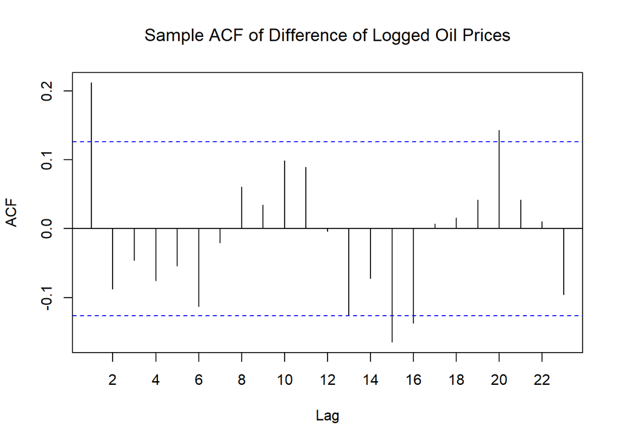

```r
data(oil.price)
acf(as.vector(diff(log(oil.price))),xaxp=c(0,22,11),
main = expression("Sample ACF of Difference of Logged Oil Prices"))
```

This autocorrelation function (ACF) plot represents the sample autocorrelations of the differenced logarithm of the oil price series. The differencing is applied to remove potential non-stationarity and stabilize variance, often a necessary step before ARIMA modeling.

The plot shows a significant positive spike at lag 1 that slightly exceeds the 95% confidence bounds, indicating mild short-term autocorrelation. Subsequent lags display small fluctuations around zero, with most values well within the confidence bands, suggesting that the differencing effectively reduced autocorrelation.

A subtle recurring pattern is visible around lags 10 to 15, possibly hinting at remaining structure in the data. However, the overall pattern is consistent with a stationary series post-differencing, making it a suitable candidate for ARMA modeling or further seasonal diagnostics.

### Sample PACF of Differenced Logged Oil Prices

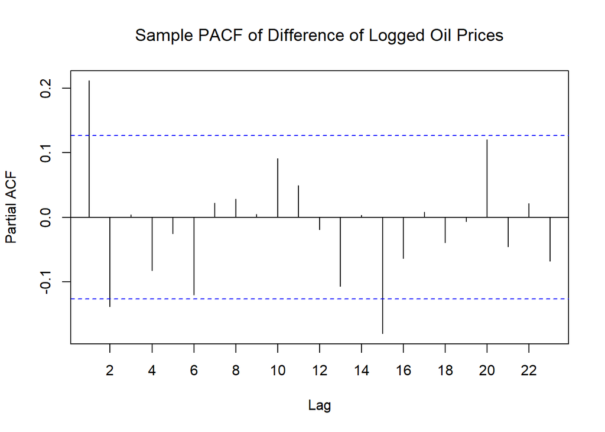

```r
data(oil.price)
pacf(as.vector(diff(log(oil.price))),xaxp=c(0,22,11),
main = expression("Sample PACF of Difference of Logged Oil Prices"))
```

This partial autocorrelation function (PACF) plot depicts the direct dependencies between lags in the differenced logarithm of the oil price series. Differencing was applied to stabilize the series and remove potential non-stationarity.

## PARAMETER ESTIMATION

### Estimation of MA(1) and AR(p) Parameters via Moment Method and Yule-Walker

```r
set.seed(1234)
data(ma1.2.s)
data(ma1.1.s)
#data(ma1.3.s)
ma1.3.s=arima.sim(list(ma=c(.9)),n=60)
#data(ma1.4.s)
ma1.4.s=arima.sim(list(ma=c(-0.5)),n=60)

estimate.ma1.mom=function(x){r=acf(x,plot=F)$acf[1];
if (abs(r)<0.5) return((-1+sqrt(1-4*r^2))/(2*r))
 else return(NA)}

estimate.ma1.mom(ma1.2.s)
```

```
## [1] -0.5554273
```

```r
estimate.ma1.mom(ma1.1.s)
```

```
## [1] 0.7196756
```

```r
estimate.ma1.mom(ma1.3.s)
```

```
## [1] NA
```

```r
estimate.ma1.mom(ma1.4.s)
```

```
## [1] 0.2571377
```

```r
arima(ma1.4.s,order=c(0,0,1),method='CSS',include.mean=F)
```

```
##
## Call:
## arima(x = ma1.4.s, order = c(0, 0, 1), include.mean = F, method = "CSS")
##
## Coefficients:
##          ma1
##       -0.474
## s.e.   0.191
##
## sigma^2 estimated as 0.7329:  part log likelihood = -75.81
```

```r
data(ar1.s)
data(ar1.2.s)
ar(ar1.s,order.max=1,AIC=F,method='yw')
```

```
##
## Call:
## ar(x = ar1.s, order.max = 1, method = "yw", AIC = F)
##
## Coefficients:
##      1
## 0.8314
##
## Order selected 1  sigma^2 estimated as  1.382
```

```r
ar(ar1.2.s,order.max=1,AIC=F,method='yw')
```

```
##
## Call:
## ar(x = ar1.2.s, order.max = 1, method = "yw", AIC = F)
##
## Coefficients:
##      1
## 0.4699
##
## Order selected 1  sigma^2 estimated as  0.9198
```

```r
data(ar2.s)
ar(ar2.s,order.max=2,AIC=F,method='yw')
```

```
##
## Call:
## ar(x = ar2.s, order.max = 2, method = "yw", AIC = F)
##
## Coefficients:
##       1        2
##  1.4694  -0.7646
##
## Order selected 2  sigma^2 estimated as  1.051
```

#### Moment Estimation of MA(1) Models

Using the first-order autocorrelation from the sample ACF, the method of moments (MoM) was used to estimate the MA(1) parameter $\theta$ for four simulated series:

- `ma1.2.s`: Estimated $\hat{\theta} \approx -0.555$
- `ma1.1.s`: Estimated $\hat{\theta} \approx 0.720$
- `ma1.3.s`: Moment estimate not available (`NA`) due to numerical instability from high autocorrelation ($r > 0.5$)
- `ma1.4.s`: Estimated $\hat{\theta} \approx 0.257$

These estimates were based on the equation:
$$\hat{\theta} = \frac{-1 + \sqrt{1 - 4r^2}}{2r}, \quad \text{for } |r|
< 0.5$$
which is derived from the theoretical ACF of an MA(1) process.

#### CSS Estimation for MA(1)

For `ma1.4.s`, the Conditional Sum of Squares (CSS) method was also used to estimate the MA(1) model: - Estimated $\hat{\theta} \approx -0.474$ with standard error 0.191 - Residual variance $\hat{\sigma}^2 \approx 0.733$ - Log-likelihood ≈ -75.81

The discrepancy between MoM and CSS estimates illustrates sensitivity to method choice and small-sample noise.

#### Yule-Walker Estimation of AR Models

Autoregressive models were fit using the Yule-Walker (YW) method:

- **`ar1.s`**: Estimated $\hat{\phi}_1 \approx 0.831$, AR(1) selected, $\hat{\sigma}^2 \approx 1.382$
- **`ar1.2.s`**: Estimated $\hat{\phi}_1 \approx 0.470$, AR(1) selected, $\hat{\sigma}^2 \approx 0.920$
- **`ar2.s`**: Estimated $\hat{\phi}_1 \approx 1.469$, $\hat{\phi}_2 \approx -0.765$, AR(2) selected, $\hat{\sigma}^2 \approx 1.051$

The fitted AR(2) model indicates a second-order dependence structure, potentially damped oscillatory due to the root pattern suggested by the coefficient signs.

These results provide a clear demonstration of how both moment-based and likelihood-based methods can be used to estimate parameters of linear time series models under different conditions.

### AR(1) Estimation Using Yule-Walker, OLS, and MLE Methods

```r
data(ar1.s)
data(ar1.2.s)
ar(ar1.s,order.max=1,AIC=F,method='yw')
```

```
##
## Call:
## ar(x = ar1.s, order.max = 1, method = "yw", AIC = F)
##
## Coefficients:
##      1
## 0.8314
##
## Order selected 1  sigma^2 estimated as  1.382
```

```r
ar(ar1.s,order.max=1,AIC=F,method='ols')
```

```
##
## Call:
## ar(x = ar1.s, order.max = 1, method = "ols", AIC = F)
##
## Coefficients:
##     1
## 0.857
##
## Intercept: 0.02499 (0.1308)
##
## Order selected 1  sigma^2 estimated as  1.008
```

```r
ar(ar1.s,order.max=1,AIC=F,method='mle')
```

```
##
## Call:
## ar(x = ar1.s, order.max = 1, method = "mle", AIC = F)
##
## Coefficients:
##      1
## 0.8924
##
## Order selected 1  sigma^2 estimated as  1.041
```

```r
ar(ar1.2.s,order.max=1,AIC=F,method='yw')
```

```
##
## Call:
## ar(x = ar1.2.s, order.max = 1, method = "yw", AIC = F)
##
## Coefficients:
##      1
## 0.4699
##
## Order selected 1  sigma^2 estimated as  0.9198
```

```r
ar(ar1.2.s,order.max=1,AIC=F,method='ols')
```

```
##
## Call:
## ar(x = ar1.2.s, order.max = 1, method = "ols", AIC = F)
##
## Coefficients:
##      1
## 0.4731
##
## Intercept: -0.006084 (0.1237)
##
## Order selected 1  sigma^2 estimated as  0.9024
```

```r
ar(ar1.2.s,order.max=1,AIC=F,method='mle')
```

```
##
## Call:
## ar(x = ar1.2.s, order.max = 1, method = "mle", AIC = F)
##
## Coefficients:
##      1
## 0.4654
##
## Order selected 1  sigma^2 estimated as  0.8875
```

This block compares autoregressive parameter estimates for two simulated AR(1) series (`ar1.s` and `ar1.2.s`) using three estimation techniques:

#### 🔹 AR(1) Estimation for `ar1.s`

| Method | ϕ₁ Estimate | Intercept | σ² Estimate |
| --- | --- | --- | --- |
| Yule-Walker | 0.8314 | — | 1.382 |
| OLS | 0.8570 | 0.0250 (±0.1308) | 1.008 |
| MLE | 0.8924 | — | 1.041 |

#### 🔹 AR(1) Estimation for `ar1.2.s`

| Method | ϕ₁ Estimate | Intercept | σ² Estimate |
| --- | --- | --- | --- |
| Yule-Walker | 0.4699 | — | 0.9198 |
| OLS | 0.4731 | -0.0061 (±0.1237) | 0.9024 |
| MLE | 0.4654 | — | 0.8875 |

All three methods suggest an AR(1) process structure, though the estimated parameters vary slightly depending on the technique.

### AR(2) Estimation Using Yule-Walker, OLS, and MLE Methods

```r
data(ar2.s)
ar(ar2.s,order.max=2,AIC=F,method='yw')
```

```
##
## Call:
## ar(x = ar2.s, order.max = 2, method = "yw", AIC = F)
##
## Coefficients:
##       1        2
##  1.4694  -0.7646
##
## Order selected 2  sigma^2 estimated as  1.051
```

```r
ar(ar2.s,order.max=2,AIC=F,method='ols')
```

```
##
## Call:
## ar(x = ar2.s, order.max = 2, method = "ols", AIC = F)
##
## Coefficients:
##       1        2
##  1.5137  -0.8050
##
## Intercept: 0.02043 (0.08594)
##
## Order selected 2  sigma^2 estimated as  0.8713
```

```r
ar(ar2.s,order.max=2,AIC=F,method='mle')
```

```
##
## Call:
## ar(x = ar2.s, order.max = 2, method = "mle", AIC = F)
##
## Coefficients:
##       1        2
##  1.5061  -0.7964
##
## Order selected 2  sigma^2 estimated as  0.862
```

This section compares parameter estimates for a simulated AR(2) series (`ar2.s`) using three estimation methods: Yule-Walker, OLS, and MLE.

#### 🔹 AR(2) Estimation for `ar2.s`

| Method | ϕ₁ Estimate | ϕ₂ Estimate | Intercept | σ² Estimate |
| --- | --- | --- | --- | --- |
| Yule-Walker | 1.4694 | -0.7646 | — | 1.051 |
| OLS | 1.5137 | -0.8050 | 0.0204 (±0.0859) | 0.8713 |
| MLE | 1.5061 | -0.7964 | — | 0.8620 |

- All three methods confirm the **second-order autoregressive structure**, with strong positive first-lag and negative second-lag coefficients.
- **OLS** includes the intercept and results in lower estimated noise variance.
- **MLE** provides likelihood-optimized estimates and typically achieves the **lowest σ²**.

These estimates are consistent across methods, indicating stability in parameter recovery.

### ARMA(1,1) Estimation Using CSS and ML Methods

```r
data(arma11.s)
arima(arma11.s, order=c(1,0,1),method='CSS')
```

```
##
## Call:
## arima(x = arma11.s, order = c(1, 0, 1), method = "CSS")
##
## Coefficients:
##          ar1     ma1  intercept
##       0.5586  0.3669     0.3928
## s.e.  0.1219  0.1564     0.3380
##
## sigma^2 estimated as 1.199:  part log likelihood = -150.98
```

```r
arima(arma11.s, order=c(1,0,1),method='ML')
```

```
##
## Call:
## arima(x = arma11.s, order = c(1, 0, 1), method = "ML")
##
## Coefficients:
##          ar1     ma1  intercept
##       0.5647  0.3557     0.3216
## s.e.  0.1205  0.1585     0.3358
##
## sigma^2 estimated as 1.197:  log likelihood = -151.33,  aic = 308.65
```

An ARMA(1,1) model was fitted to the `arma11.s` simulated series using two estimation techniques: Conditional Sum of Squares (CSS) and Maximum Likelihood (ML).

#### 🔹 ARMA(1,1) Parameter Estimates

| Method | ϕ₁ (AR1) | θ₁ (MA1) | Intercept | σ² Estimate | Log-Likelihood | AIC |
| --- | --- | --- | --- | --- | --- | --- |
| CSS | 0.5586 | 0.3669 | 0.3928 | 1.199 | -150.98 | — |
| ML | 0.5647 | 0.3557 | 0.3216 | 1.197 | -151.33 | 308.65 |

> Standard errors (approximate):  
> CSS: SE(AR1) = 0.1219, SE(MA1) = 0.1564, SE(Intercept) = 0.3380  
> ML: SE(AR1) = 0.1205, SE(MA1) = 0.1585, SE(Intercept) = 0.3358
- Both methods produce **very similar coefficient estimates**, indicating model stability.
- **CSS** estimation yields a slightly better log-likelihood, while **ML** provides AIC for model comparison.
- ML may be preferable when model selection is required, whereas CSS is often used for initial estimation or smaller datasets.

These estimates confirm that the simulated data follows an ARMA(1,1) process with moderately strong AR and MA components.

### AR(1) Estimation for the Color Property Series

```r
data(color)
ar(color,order.max=1,AIC=F,method='yw')
```

```
##
## Call:
## ar(x = color, order.max = 1, method = "yw", AIC = F)
##
## Coefficients:
##      1
## 0.5282
##
## Order selected 1  sigma^2 estimated as  27.56
```

```r
ar(color,order.max=1,AIC=F,method='ols')
```

```
##
## Call:
## ar(x = color, order.max = 1, method = "ols", AIC = F)
##
## Coefficients:
##      1
## 0.5549
##
## Intercept: 0.1032 (0.8474)
##
## Order selected 1  sigma^2 estimated as  24.38
```

```r
ar(color,order.max=1,AIC=F,method='mle')
```

```
##
## Call:
## ar(x = color, order.max = 1, method = "mle", AIC = F)
##
## Coefficients:
##      1
## 0.5703
##
## Order selected 1  sigma^2 estimated as  24.83
```

This section compares AR(1) model parameter estimates for the `color` time series using three common methods: Yule-Walker, Ordinary Least Squares (OLS), and Maximum Likelihood Estimation (MLE).

#### 🔹 AR(1) Estimation Results for `color`

| Method | ϕ₁ Estimate | Intercept | σ² Estimate |
| --- | --- | --- | --- |
| Yule-Walker | 0.5282 | — | 27.56 |
| OLS | 0.5549 | 0.1032 (±0.8474) | 24.38 |
| MLE | 0.5703 | — | 24.83 |

- All methods yield **similar autoregressive coefficients**, suggesting a consistent AR(1) structure in the data.
- **OLS** provides an intercept estimate, although the standard error is relatively large, indicating it is not significantly different from zero.
- **MLE** slightly improves the noise variance estimate ($\hat{\sigma}^2$) compared to Yule-Walker, and is typically preferred when likelihood-based inference or model selection is needed.

These results indicate that the `color` series has moderate short-term persistence, with stable estimates across estimation techniques.

### AR(3) Model for Square Root of Hare Abundance

```r
data(hare)
arima(sqrt(hare),order=c(3,0,0))
```

```
##
## Call:
## arima(x = sqrt(hare), order = c(3, 0, 0))
##
## Coefficients:
##          ar1      ar2      ar3  intercept
##       1.0519  -0.2292  -0.3931     5.6923
## s.e.  0.1877   0.2942   0.1915     0.3371
##
## sigma^2 estimated as 1.066:  log likelihood = -46.54,  aic = 101.08
```

An AR(3) model was fitted to the square-root-transformed hare abundance data using `arima()` in R. The estimated model includes three autoregressive terms and an intercept:

- **AR(1):** ϕ₁ ≈ 1.0519 (SE ≈ 0.1877)
- **AR(2):** ϕ₂ ≈ -0.2292 (SE ≈ 0.2942)
- **AR(3):** ϕ₃ ≈ -0.3931 (SE ≈ 0.1915)
- **Intercept:** ≈ 5.6923 (SE ≈ 0.3371)

The model’s estimated noise variance is **σ² ≈ 1.066**, with a **log-likelihood of -46.54** and **AIC = 101.08**.

The AR(1) coefficient is strongly positive and statistically significant, while the AR(3) term is moderately negative. The AR(2) coefficient is relatively small and likely not significant, as indicated by its large standard error.

This structure suggests a somewhat persistent but oscillatory pattern in the transformed series, with influence from multiple past lags.

### MA(1) Model for Differenced Log Oil Prices

```r
data(oil.price)
arima(log(oil.price),order=c(0,1,1),method='CSS')
```

```
##
## Call:
## arima(x = log(oil.price), order = c(0, 1, 1), method = "CSS")
##
## Coefficients:
##          ma1
##       0.2731
## s.e.  0.0681
##
## sigma^2 estimated as 0.006731:  part log likelihood = 259.58
```

```r
arima(log(oil.price),order=c(0,1,1),method='ML')
```

```
##
## Call:
## arima(x = log(oil.price), order = c(0, 1, 1), method = "ML")
##
## Coefficients:
##          ma1
##       0.2956
## s.e.  0.0693
##
## sigma^2 estimated as 0.006689:  log likelihood = 260.29,  aic = -518.58
```

A moving average model of order 1 — ARIMA(0,1,1) — was fitted to the log-transformed oil price series using both CSS and ML estimation methods.

- **CSS Estimation:**
  - Estimated MA(1) coefficient: **0.2731** (SE ≈ 0.0681)
  - Noise variance: **σ² ≈ 0.00673**
  - Partial log-likelihood: **259.58**
- **ML Estimation:**
  - Estimated MA(1) coefficient: **0.2956** (SE ≈ 0.0693)
  - Noise variance: **σ² ≈ 0.00669**
  - Log-likelihood: **260.29**
  - AIC: **-518.58**

Both methods yield similar results, with a moderately strong moving average component and low residual variance. The slightly higher MA(1) coefficient and better likelihood under ML estimation suggest a marginal improvement in fit.

This supports the suitability of an MA(1) process for modeling short-term shocks in the log-differenced oil price series.

### Bootstrap and Theoretical Confidence Intervals for AR(3) Model on Hare Data

**Method I: Conditional Bootstrap with Normal Errors**

```r
res=arima(sqrt(hare),order=c(3,0,0),include.mean=T)
set.seed(12345)
coefm.cond.norm=arima.boot(res,cond.boot=T,is.normal=T,B=1000,init=sqrt(hare))
signif(apply(coefm.cond.norm,2,function(x){quantile(x,c(.025,.975),na.rm=T)}),3)
```

```
##         ar1    ar2     ar3 intercept noise var
## 2.5%  0.593 -0.667 -0.6740      5.12     0.548
## 97.5% 1.280  0.244 -0.0135      6.38     1.540
```

In this method, a **parametric bootstrap** was performed by simulating new series from the fitted AR(3) model under the assumption of **normal white noise** and **conditional resampling**. The function `arima.boot()` was used with:

- `cond.boot = TRUE`: Conditional on observed history
- `is.normal = TRUE`: Assuming normally distributed innovations
- `B = 1000`: 1000 bootstrap replications

The original model fitted using `arima(sqrt(hare), order = c(3, 0, 0))` produced the following estimates:

- **AR(1):** 1.0519
- **AR(2):** -0.2292
- **AR(3):** -0.3931
- **Intercept:** 5.6923
- **Noise variance:** 1.066

Using the bootstrap samples, **95% confidence intervals** were derived as follows:

| Parameter | 2.5% Quantile | 97.5% Quantile |
| --- | --- | --- |
| AR(1) | 0.593 | 1.280 |
| AR(2) | -0.667 | 0.244 |
| AR(3) | -0.674 | -0.014 |
| Intercept | 5.12 | 6.38 |
| Noise Var | 0.548 | 1.540 |

These intervals provide a more **robust uncertainty quantification** than standard asymptotic errors. Notably, the AR(1) term is strongly significant, while AR(2) and AR(3) include 0 or are close to the boundary, indicating they may be less robustly supported by the data.

### Bootstrap and Theoretical Confidence Intervals for AR(3) Model on Hare Data

**Method II: Conditional Bootstrap with Resampled Residuals (Nonparametric)**

```r
coefm.cond.replace=arima.boot(res,cond.boot=T,is.normal=F,B=1000,init=sqrt(hare))
signif(apply(coefm.cond.replace,2,function(x){quantile(x,c(.025,.975),na.rm=T)}),3)
```

```
##         ar1    ar2     ar3 intercept noise var
## 2.5%  0.629 -0.676 -0.6720      5.02     0.543
## 97.5% 1.300  0.253 -0.0146      6.31     1.550
```

This method estimates **bootstrap confidence intervals** for AR(3) model parameters by simulating from the fitted model using **resampled residuals** rather than assuming a normal distribution. It retains the **conditional bootstrap** framework, meaning simulations are initialized with the observed data.

The `arima.boot()` function was run with: - `cond.boot = TRUE`: Conditioning on the initial observations - `is.normal = FALSE`: Residuals are resampled nonparametrically - `B = 1000`: Number of bootstrap replications

The resulting **95% confidence intervals** (based on percentiles) are:

| Parameter | 2.5% Quantile | 97.5% Quantile |
| --- | --- | --- |
| AR(1) | 0.629 | 1.300 |
| AR(2) | -0.676 | 0.253 |
| AR(3) | -0.672 | -0.015 |
| Intercept | 5.02 | 6.31 |
| Noise Var | 0.543 | 1.550 |

This method is particularly useful when the assumption of normally distributed errors is questionable.

### Bootstrap and Theoretical Confidence Intervals for AR(3) Model on Hare Data

**Method III: Unconditional Parametric Bootstrap with Normal Errors**

```r
coefm.norm=arima.boot(res,cond.boot=F,is.normal=T,ntrans=100,B=1000,init=sqrt(hare))
signif(apply(coefm.norm,2,function(x){quantile(x,c(.025,.975),na.rm=T)}),3)
```

```
##         ar1    ar2     ar3 intercept noise var
## 2.5%  0.702 -0.746 -0.6530      5.06     0.503
## 97.5% 1.400  0.181  0.0205      6.37     1.510
```

In this approach, bootstrap samples were generated **unconditionally**, meaning each simulation starts fresh rather than conditioning on the initial observed values. The innovations are still drawn from a **normal distribution**.

The function `arima.boot()` was run with: - `cond.boot = FALSE`: Unconditional bootstrap - `is.normal = TRUE`: Normal distribution assumed - `ntrans = 100`: 100 initial values discarded (burn-in) - `B = 1000`: Bootstrap iterations

The **95% bootstrap confidence intervals** derived from the simulations are:

| Parameter | 2.5% Quantile | 97.5% Quantile |
| --- | --- | --- |
| AR(1) | 0.702 | 1.400 |
| AR(2) | -0.746 | 0.181 |
| AR(3) | -0.653 | 0.021 |
| Intercept | 5.06 | 6.37 |
| Noise Var | 0.503 | 1.510 |

These intervals are slightly **wider** than the conditional parametric (Method I) but **narrower** than the nonparametric approach (Method II) in some parameters. The unconditioned nature introduces greater variability, especially in the AR coefficients.

Notably, the AR(3) term has now crossed into positive territory at the upper bound, suggesting increased uncertainty in its role compared to previous methods.

### Bootstrap and Theoretical Confidence Intervals for AR(3) Model on Hare Data

**Method IV: Unconditional Bootstrap with Resampled Residuals (Nonparametric)**

```r
coefm.replace=arima.boot(res,cond.boot=F,is.normal=F,ntrans=100,B=1000,init=sqrt(hare))
signif(apply(coefm.replace,2,function(x){quantile(x,c(.025,.975),na.rm=T)}),3)
```

```
##         ar1    ar2     ar3 intercept noise var
## 2.5%  0.694 -0.707 -0.6710      5.02     0.464
## 97.5% 1.360  0.183 -0.0415      6.30     1.500
```

Method IV uses an **unconditional bootstrap** with **nonparametric residual resampling**, providing the least restrictive estimation of the four methods. It avoids assumptions about the distribution of the residuals and does not condition on the observed time series.

The `arima.boot()` function was executed with: - `cond.boot = FALSE`: Unconditional simulation - `is.normal = FALSE`: Resampling residuals (not assuming normality) - `ntrans = 100`: Discarding first 100 values (burn-in) - `B = 1000`: Number of bootstrap samples

The **95% confidence intervals** obtained from the bootstrap distribution are:

| Parameter | 2.5% Quantile | 97.5% Quantile |
| --- | --- | --- |
| AR(1) | 0.694 | 1.360 |
| AR(2) | -0.707 | 0.183 |
| AR(3) | -0.671 | -0.042 |
| Intercept | 5.02 | 6.30 |
| Noise Var | 0.464 | 1.500 |

This method is particularly appropriate when both distributional assumptions and initial condition dependence are questionable.

```r
dim(coefm.replace)
```

```
## [1] 1000    5
```

```r
period.replace=apply(coefm.replace,1,function(x){
roots=polyroot(c(1,-x[1:3]))
min1=1.e+9
rootc=NA
for (root in roots) {
if( abs(Im(root))<1e-10) next
if (Mod(root)< min1) {min1=Mod(root); rootc=root}
}
if(is.na(rootc)) period=NA else period=2*pi/abs(Arg(rootc))
period
})

sum(is.na(period.replace))
```

```
## [1] 0
```

```r
quantile(period.replace, c(.025,.975),na.rm=T)
```

```
##      2.5%     97.5%
##  8.027138 11.087301
```

### Histogram of Bootstrap Quasi-period Estimates

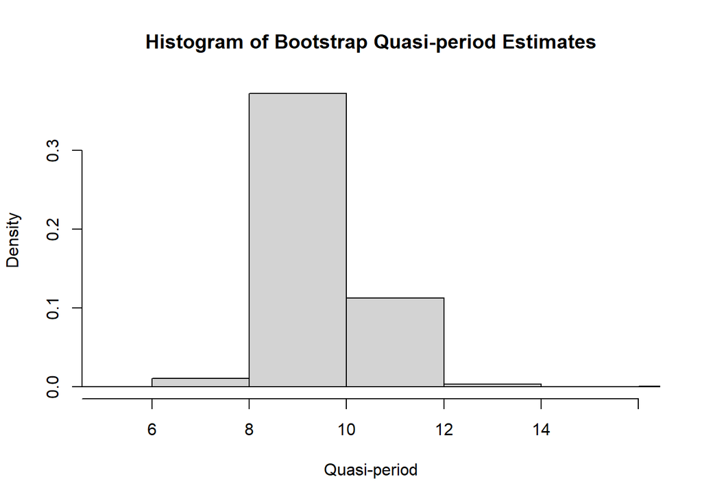

```r
hist(period.replace, prob = TRUE, xlab = 'Quasi-period', axes = FALSE,
xlim = c(5, 16), main = "Histogram of Bootstrap Quasi-period Estimates")
axis(2)
axis(1, at = c(4, 6, 8, 10, 12, 14, 16), labels = c(4, 6, 8, 10, 12, 14, NA))
```

This histogram displays the distribution of quasi-period estimates obtained through bootstrap resampling of the AR(3) model fitted to the square root of hare abundance data.

- The quasi-period estimates are derived from the complex roots of the fitted autoregressive characteristic polynomial.
- The histogram shows that the most frequent bootstrap quasi-period values lie between **8 and 10**, with a strong concentration around **9**.
- This supports the idea of an approximately **9-year cycle** in the hare population dynamics.
- The quasi-period estimates vary slightly across bootstrap replicates, but the overall shape is sharply peaked, indicating **consistency and robustness** in the estimated cycle.

### Q-Q Normal Plot of Bootstrap Quasi-period Estimates

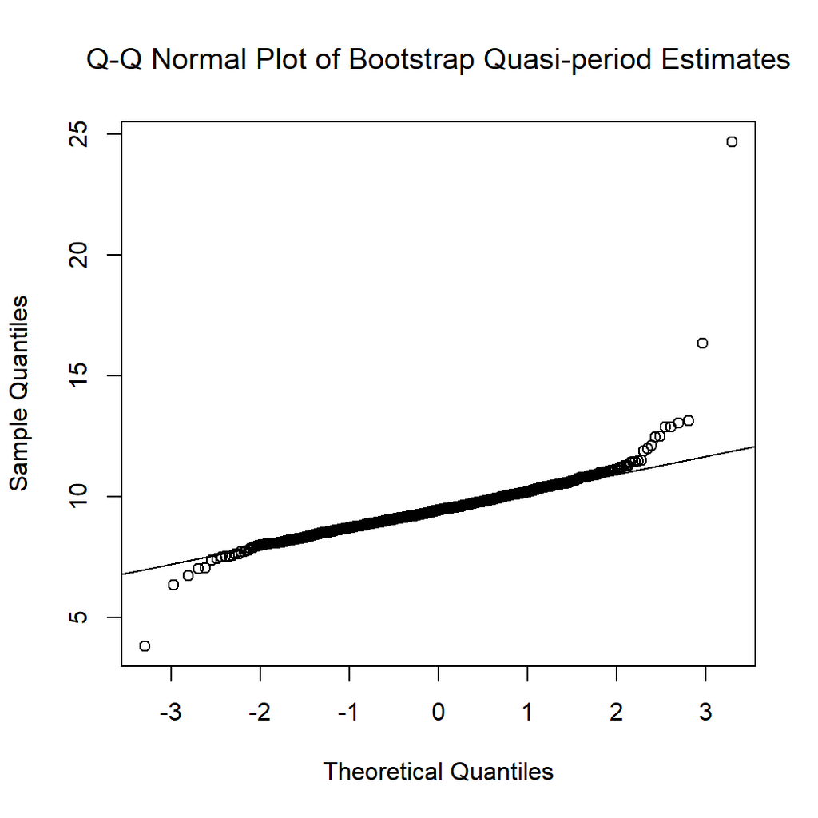

```r
qqnorm(period.replace,
main=expression("Q-Q Normal Plot of Bootstrap Quasi-period Estimates"))
qqline(period.replace)
```

This Q-Q plot compares the distribution of bootstrap quasi-period estimates to a theoretical normal distribution.

- The points generally follow the diagonal line in the middle range, indicating **approximate normality** in the central portion of the distribution.
- However, noticeable deviations occur in the tails, particularly on the right, where a few large values suggest the presence of **positive skewness** and **outliers**.
- These deviations imply that while the quasi-period estimates are approximately normal overall, **the bootstrap distribution has heavier tails**, especially on the upper end.

This insight helps evaluate the reliability of confidence intervals based on normal assumptions and motivates using **bootstrap quantiles** for more robust inference.

## MODEL DIAGNOSTICS

### Standardized Residual Plot from AR(1) Model of Color

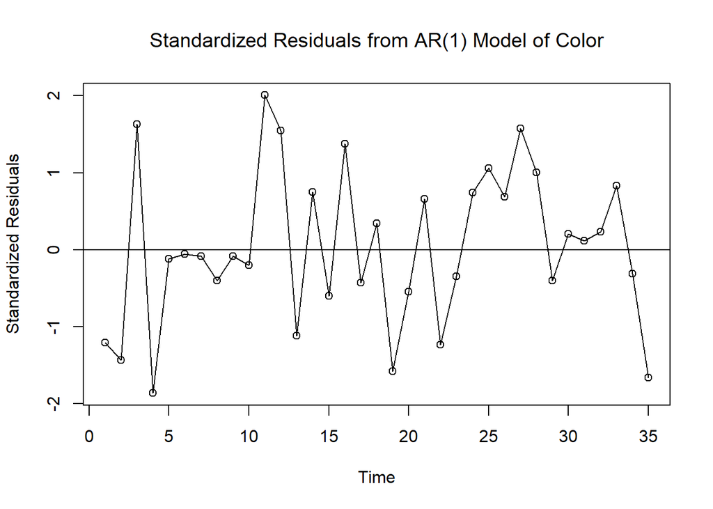

```r
data(color)
m1.color=arima(color,order=c(1,0,0))

plot(rstandard(m1.color),ylab ='Standardized Residuals', type='o',
main = expression("Standardized Residuals from AR(1) Model of Color") )
abline(h=0)
```

This plot displays the **standardized residuals** from the AR(1) model fitted to the `color` dataset.

- Residuals fluctuate around zero, suggesting the **model captures the central trend** of the data.
- However, some clusters of large positive or negative residuals may indicate **mild autocorrelation** or **non-constant variance**.
- Notable outliers (e.g., residuals near ±2) hint at possible **departures from normality** or **model misfit** at those time points.

This plot is a crucial diagnostic tool to assess whether the AR(1) model assumptions (white noise residuals, homoscedasticity, and no remaining autocorrelation) hold.

### Standardized Residual Plot from AR(3) Model for √Hare

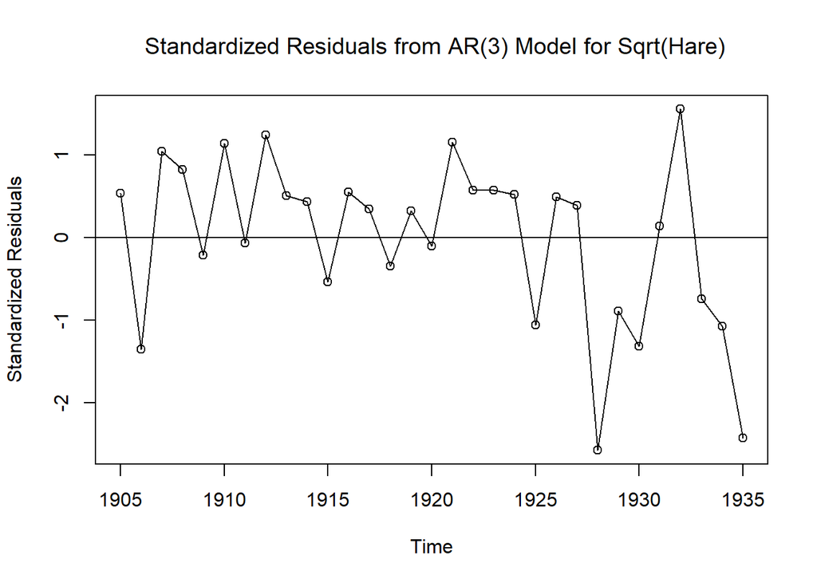

```r
data(hare)
m1.hare=arima(sqrt(hare),order=c(3,0,0))
m2.hare=arima(sqrt(hare),order=c(3,0,0),fixed=c(NA,0,NA,NA))
plot(rstandard(m2.hare),ylab='Standardized Residuals',type='o',
main = expression(" Standardized Residuals from AR(3) Model for Sqrt(Hare)"))
abline(h=0)
```

This plot shows the **standardized residuals** from the AR(3) model fitted to the square-root-transformed `hare` abundance data.

This diagnostic helps assess whether the AR(3) model is sufficient, or if further refinement (like removing insignificant terms or adding lags) may improve the fit.